# A Data Generating Process for Improper Payments

Author

Wade K. Copeland and Jonathan Gladish

Published

October 11, 2025 08:24:21

# Proposed Data Generating Process

The population data for payments is generated under the assumption that the data generating process for each payment is exponential $X_i \sim Exp(\lambda)$ where $\lambda = 1/E[X]$ and $E[X] = \sum_x xf(x)$ with $f(x) = Pr(X = x)$ (Bain and Engelhardt 1992, 4:115–16). To generate each improper payment let $Y_i = B_iX_iZ_i$ where $B_i \sim Unif(a \in \{0, 1\}, b > a \in \{0, 1\})$ is the percentage of each payment that is improper, and $Z_{i} \sim Bin(1,p)$, where $1$ is the number of trials and $p$ is the probability of observing an improper payment (Bain and Engelhardt 1992, 4:92–95, 109–10). The following Python code implements this data generating process for improper payments.

```python
import pandas as pd
import matplotlib.pyplot as plt
from math import ceil
from scipy.stats import uniform, binom, truncexpon
import numpy as np

def improper_payment(
    payamt: int = 1000000000,
    N: int = 1000000,
    b: tuple = (0.4, 0.6),
    lower: int = 0,
    upper: int = None,
    p_improper: float = 0.1):
    """This function generates the population data for improper payments.

    Parameters:
        - payment (int): The total payment amount.
        - N (int): The number of payments, which implies the average payment amount is payment/N.
        - b (tuple): Bounds of the uniform distribution (0 <= b <= 1) for the percentage of each payment that is improper.
        - lower (int): Lower bound on the payment amount.
        - upper (int): Upper bound on the payment amount.  If 'None' it's set as payment.
        - p_improper (float): Probability that a given payment is improper.

    Returns:
        - A Pandas DataFrame with the following:
            X: Random variates of an exponential distribution for the payment amount.
            B: Random variates of a uniform distribution for the percent of the payment that is improper.
            Z: Random variates of a binomial distribution that indicate if a payment is improper.
            Y: Random variates for the improper payment amount. Y = X*B*Z.
    """
    b = b if type(b) is tuple else (b, b)
    lim = upper if upper else payamt
    exp_lambda = 1/(payamt/N)

    B = uniform.rvs(size = N, loc = b[0], scale = b[1] - b[0])
    X = truncexpon.rvs(size = N, scale = 1/exp_lambda, b = (lim - lower)*(1/(1/exp_lambda)), loc = lower)
    Z = binom.rvs(size = N, n = 1, p = p_improper)
    Y = X*B*Z

    pop_data = pd.DataFrame({
        "X": X,
        "B": B,
        "Z": Z,
        "Y": Y})

    return pop_data
```

# Example

The following example is for a population with $1,000,000,000 in payments from 1,000,000 individual payments. This means the average payment amount is $1,000,000,000/1,000,000 = $1,000. The probability that each payment is improper is 10% and the percentage of each payment that is improper is between 40% and 60% of the payment amount.

```python
np.random.seed(123)

d = improper_payment(payamt = 1000000000, N = 1000000, b = (0.4, 0.6), lower = 0, upper = None, p_improper = 0.1)

print(f"The total payment amount is ${round(sum(d["X"]), 2):,}.\nThe probability that each payment is improper is {round(np.mean(d["Z"])*100, 2)}.\nThe average percentage of each payment that is improper is {round(np.mean(d["B"])*100, 2)}%.\nThe total improper payment amount is ${round(sum(d["Y"]), 2):,}.")
```

```
The total payment amount is $1,000,924,443.61.
The probability that each payment is improper is 9.96.
The average percentage of each payment that is improper is 50.0%.
The total improper payment amount is $50,079,671.34.
```

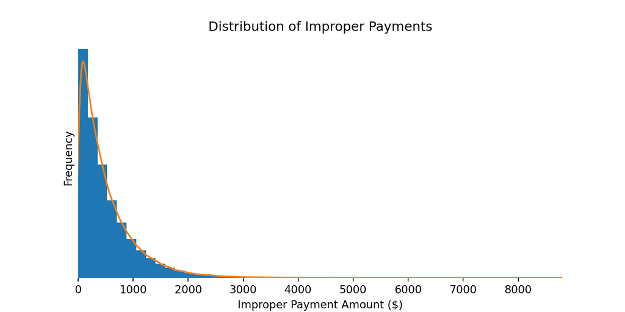

```python
def pfun():
    pdata = d["Y"][d["Y"] > 0]
    fig, ax = plt.subplots(figsize = (8, 4))
    pdata.plot(kind = "hist", density = True, bins = 50)
    pdata.plot(kind = "kde")
    ax.set_xlim(0, max(pdata))
    ax.set_xlabel("Improper Payment Amount ($)")
    ax.set_yticks([])
    ax.set_ylabel("Frequency")
    ax.set_title("Distribution of Improper Payments")
    ax.tick_params(left = False)
    for ax, spine in ax.spines.items():
        spine.set_visible(False)
    plt.savefig("improper-payments-dpg-py.svg", format='svg', dpi=300)
    plt.show()

pfun()
```

# Session Information

```
-----
matplotlib          3.10.7
numpy               2.3.3
pandas              2.3.3
scipy               1.16.2
session_info        v1.0.1
-----
Python 3.14.0 (main, Oct  7 2025, 09:34:52) [Clang 17.0.0 (clang-1700.0.13.3)]
macOS-15.6.1-arm64-arm-64bit-Mach-O
-----
Session information updated at 2025-10-11 20:24
```

## References

Bain, Lee J, and Max Engelhardt. 1992. *Introduction to Probability and Mathematical Statistics*. Vol. 4. Duxbury Press Belmont, CA.